# Logistic Regression: Additional Exercise

## Preface

### R packages

In this practical, we use the R package **ggplot2**. It can be installed by running the following syntax:

```r
install.packages("ggplot2")
```

### Dataset

Like in the previous practical on logistic regression, we will use the **pbc** dataset from the package **survival**.

You can either load the **survival** package to get access to this dataset

```r
library(survival)
```

or make a copy of this data

```r
pbc <- survival::pbc
```

The **pbc** data contain (among others) the following variables:

```r
str(pbc[, c(5:12, 20)])
```

```
## 'data.frame':    418 obs. of  9 variables:
##  $ age    : num  58.8 56.4 70.1 54.7 38.1 ...
##  $ sex    : Factor w/ 2 levels "m","f": 2 2 1 2 2 2 2 2 2 2 ...
##  $ ascites: int  1 0 0 0 0 0 0 0 0 1 ...
##  $ hepato : int  1 1 0 1 1 1 1 0 0 0 ...
##  $ spiders: int  1 1 0 1 1 0 0 0 1 1 ...
##  $ edema  : num  1 0 0.5 0.5 0 0 0 0 0 1 ...
##  $ bili   : num  14.5 1.1 1.4 1.8 3.4 0.8 1 0.3 3.2 12.6 ...
##  $ chol   : int  261 302 176 244 279 248 322 280 562 200 ...
##  $ stage  : int  4 3 4 4 3 3 3 3 2 4 ...
```

The relevant variables are

- `age`: patient’s age in years
- `sex`: patient’s sex
- `ascites`: presence of ascites
- `spiders`: presence of blood vessel malformations in the skin
- `bili`: serum bilirubin
- `chol`: serum cholesterol
- `stage`: histologic stage of the disease

## Exploring problems in logistic regression

In the previous practical, we have re-coded some of the categorical variables and fitted the logistic regression model.

If you are using a new R session, you need to first run the following syntax:

```r
pbc$stage <- factor(pbc$stage)
pbc$spiders <- factor(pbc$spiders)

mod1 <- glm(spiders ~ age + sex + bili + stage + ascites, data = pbc,
            family = binomial())
```

We would now like to add another continuous variable to `mod1`: the variable `chol`.

### Task 1

- Update `mod1` to include `chol`.
- Investigate how the results change.

### Solution 1

```r
mod_chol <- update(mod1, formula = . ~ . + chol)
summary(mod_chol)
```

```
##
## Call:
## glm(formula = spiders ~ age + sex + bili + stage + ascites +
##     chol, family = binomial(), data = pbc)
##
## Deviance Residuals:
##     Min       1Q   Median       3Q      Max
## -1.6892  -0.7688  -0.5030   0.9416   2.2690
##
## Coefficients:
##               Estimate Std. Error z value Pr(>|z|)
## (Intercept) -1.812e+01  1.074e+03  -0.017   0.9865
## age         -1.149e-02  1.518e-02  -0.757   0.4491
## sexf         1.274e+00  5.857e-01   2.175   0.0297 *
## bili         8.606e-02  3.580e-02   2.404   0.0162 *
## stage2       1.529e+01  1.074e+03   0.014   0.9886
## stage3       1.624e+01  1.074e+03   0.015   0.9879
## stage4       1.714e+01  1.074e+03   0.016   0.9873
## ascites      9.736e-02  5.765e-01   0.169   0.8659
## chol        -1.710e-04  6.779e-04  -0.252   0.8009
## ---
## Signif. codes:  0 '***' 0.001 '**' 0.01 '*' 0.05 '.' 0.1 ' ' 1
##
## (Dispersion parameter for binomial family taken to be 1)
##
##     Null deviance: 341.38  on 283  degrees of freedom
## Residual deviance: 289.81  on 275  degrees of freedom
##   (134 observations deleted due to missingness)
## AIC: 307.81
##
## Number of Fisher Scoring iterations: 16
```

We can compare the coefficients form `mod1` and `mod_chol` and notice that the `(Intercept)`, and the coefficients for `stage` are much more extreme than the ones in `mod1`:

```r
round(
  cbind(mod1 = coef(mod1)[names(coef(mod_chol))],
        mod_chol = coef(mod_chol)
  ), 3)
```

```
##               mod1 mod_chol
## (Intercept) -2.936  -18.116
## age         -0.021   -0.011
## sexf         1.213    1.274
## bili         0.099    0.086
## stage2       0.651   15.292
## stage3       1.371   16.241
## stage4       2.279   17.144
## ascites      0.262    0.097
## <NA>            NA    0.000
```

Note:

If we would just use `cbind()` to combine the coefficients into a matrix we could not be sure that the coefficients of the same variable are in the same row.

```r
a <- c(x = 1, y = 2, z = 3)
b <- c(x = 1, z = 3, y = 2)
cbind(a, b)
```

```
##   a b
## x 1 1
## y 2 3
## z 3 2
```

Moreover, the “missing” effect for `chol` in `mod1` will just be filled in with the first value of the vector.

```r
cbind(coef(mod1), coef(mod_chol))
```

```
##                    [,1]          [,2]
## (Intercept) -2.93568220 -1.811631e+01
## age         -0.02050837 -1.148978e-02
## sexf         1.21276329  1.273726e+00
## bili         0.09867415  8.606048e-02
## stage2       0.65103163  1.529183e+01
## stage3       1.37091993  1.624066e+01
## stage4       2.27857603  1.714371e+01
## ascites      0.26188382  9.736020e-02
## chol        -2.93568220 -1.709538e-04
```

By using `coef(mod1)[names(coef(mod_chol))]` we make sure that the coefficients from `mod1` are given in the same order as the coefficients from `mod_chol`. Since there is no `chol` in `coef(mod1)`, `NA` is filled in:

```r
coef(mod1)[names(coef(mod_chol))]
```

```
## (Intercept)         age        sexf        bili      stage2      stage3      stage4     ascites
## -2.93568220 -0.02050837  1.21276329  0.09867415  0.65103163  1.37091993  2.27857603  0.26188382
##        <NA>
##          NA
```

### Visualization

To compare the coefficients from different models it is useful to plot coefficients with their corresponding confidence intervals.

**Using base R plots:**

```r
# coefficients & CI from mod1
res1 <- cbind(coef = coef(mod1), confint(mod1))
res1 <- rbind(res1, chol = c(NA, NA, NA)) # add an "empty" row for chol

# coefficients & CI from mod_chol
res3 <- cbind(coef = coef(mod_chol), confint(mod_chol))
```

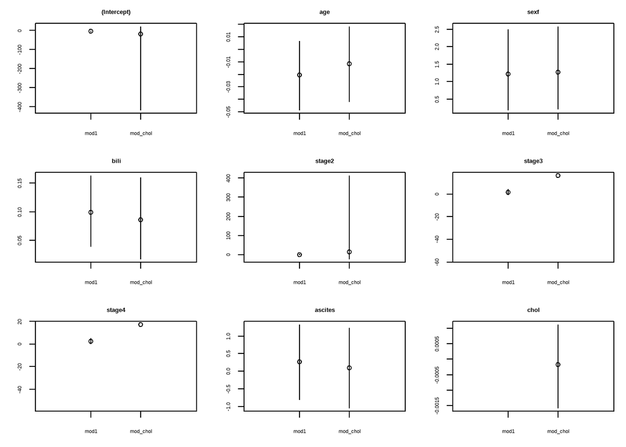

```r
# graphical settings:
# * mfrow = c(3, 3) print the plots in a grid with 3 rows and 3 columns
# * mar = c(3, 3, 2, 1): adjust the plot margins (looks nicer)
par(mfrow = c(3, 3), mar = c(3, 3, 2, 1))

for (k in rownames(res1)) {                               # loop over all variables
  plot(x = c(1, 2),                                       # position on the x-axis
       y = c(res1[k, 'coef'], res3[k, 'coef']),           # coefficient value on the y-axis
       main = k,                                          # set variable name as title
       xlim = c(0, 3),                                    # set limit of the x-axis (looks nicer)
       ylim = range(res1[k, ], res3[k, ], na.rm = TRUE),  # set the limits of the y-axis
                                                          # so that also the CIs fit in
       xaxt = 'n',                                        # don't plot the x-axis (we want our own version)
       ylab = 'log OR & 95% CI')                          # specify the y-axis label

  # specification of the x-axis
  axis(side = 1,                    # draw axis at the bottom of the plot
       at = c(1, 2),                # locations of the tick-marks on the x-axis
       labels = c('mod1', 'mod_chol'))  # labels of the tick-marks

  # add vertical lines representing the confidence intervals
  lines(x = c(1, 1), y = res1[k, c('2.5 %', '97.5 %')])
  lines(x = c(2, 2), y = res3[k, c('2.5 %', '97.5 %')])
}
```

**Using ggplot2:**

```r
results <- rbind(
  # data.frame containing results from mod1
  data.frame(coef = coef(mod1),
             confint(mod1),
             variable = names(coef(mod1)),
             model = 'mod1',
             check.names = FALSE),

  # data.frame containing results from mod_chol
  data.frame(coef = coef(mod_chol),
             confint(mod_chol),
             variable = names(coef(mod_chol)),
             model = 'mod_chol',
             check.names = FALSE)
)
```

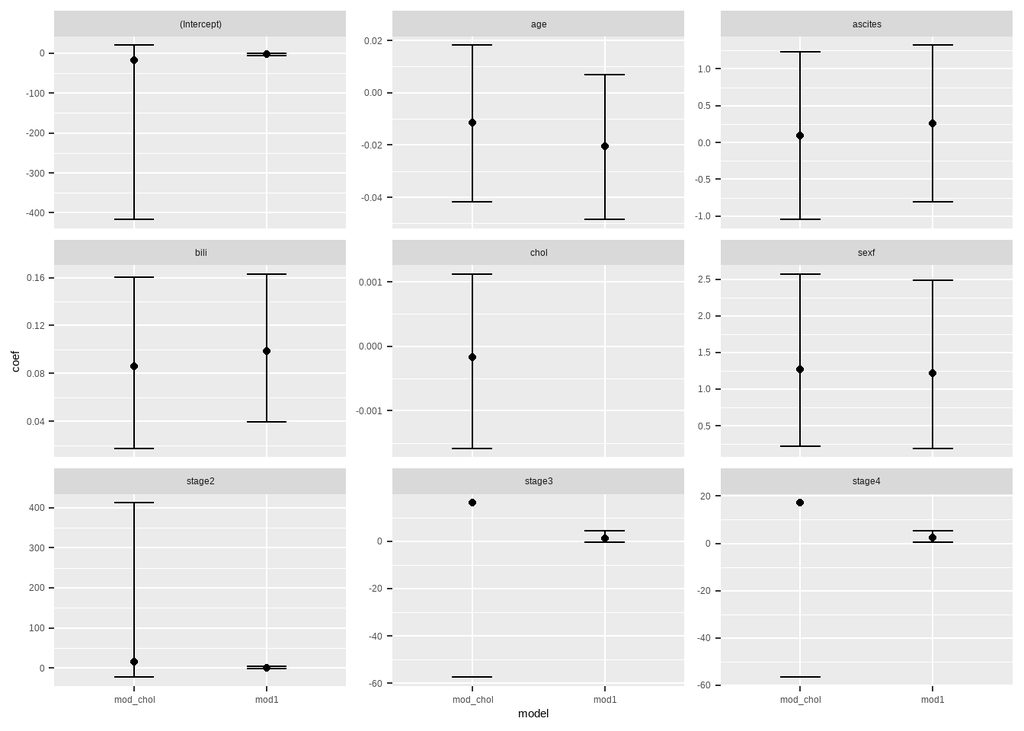

```r
library("ggplot2")
ggplot(results,                           # specification of the data
       aes(x = model, y = coef)) +        # specify what goes on which axis
  geom_point() +                          # plot points for the coefficients
  geom_errorbar(aes(ymin = `2.5 %`,       # add confidence intervals
                    ymax = `97.5 %`),
                width = 0.3) +            # width of the horizontal lines
  facet_wrap('variable',                  # make a separate plot per variable
             scales = 'free_y')           # allow the y-axes to vary between variables
```

### Task 2

Something is clearly going wrong with the variable `stage`.

Investigate what is going on by looking at `stage` in relation to the outcome `spiders`.

Use a `table()`.

### Solution 2

```r
table(stage = pbc$stage,
      spiders = pbc$spiders, exclude = NULL)
```

```
##       spiders
## stage   0  1 <NA>
##   1    15  1    5
##   2    58  9   25
##   3    90 30   35
##   4    59 50   35
##   <NA>  0  0    6
```

### Task 3

We saw that there is almost perfect separation between `spiders` for the patients with `stage = 1`, but as long as there is a patient, for every combination of covariate and outcome, we should not get such non-sense results.

We may have overlooked something when we created the table.

Check if the table did indeed include those cases that are analysed in `mod_chol` by checking if the table at least contains the correct number of cases.

You can find relevant info in the output of the `summary()`.

### Solution 3

```r
sum(table(stage = pbc$stage, spiders = pbc$spiders))
```

```
## [1] 312
```

In the table, we have 312 cases where both `spiders` and `stage` are observed.

The output of `summary(mod_chol)` showed the following:

```
## [...]
##     Null deviance: 341.38  on 283  degrees of freedom
## Residual deviance: 289.81  on 275  degrees of freedom
##   (134 observations deleted due to missingness)
## AIC: 307.81
##
## Number of Fisher Scoring iterations: 16
```

134 observations were excluded.

In the full **pbc** data we have `nrow(pbc) = 418` observations.

We should, hence, be looking at only `418 - 134 = 284` observations!

There are some other variables in our model that have missing values!

Note:

The output of `summary(mod_chol)`) also shows that the deviance of the null model (the model with only intercept) had 283 degrees of freedom, which is N - 1. We could also derive from there that there were 283 + 1 cases in the analysis.

### Task 4

We need to exclude all cases that have missing values in any of the variables involved in `mod_chol` and check the table of `stage` and `spiders` again.

- Check which variables have missing values.
- Make a subset excluding those cases.
- Create the table of `stage` vs `spiders` using the subset.

### Solution 4

A convenient way to obtain all variables from a model is to use the function `all.vars()` on the model formula:

```r
all.vars(formula(mod_chol))
```

```
## [1] "spiders" "age"     "sex"     "bili"    "stage"   "ascites" "chol"
```

We can use this to get a summary of exactly those columns of the **pbc** data:

```r
summary(pbc[, all.vars(formula(mod_chol))])
```

```
##  spiders         age        sex          bili         stage        ascites             chol
##  0   :222   Min.   :26.28   m: 44   Min.   : 0.300   1   : 21   Min.   :0.00000   Min.   : 120.0
##  1   : 90   1st Qu.:42.83   f:374   1st Qu.: 0.800   2   : 92   1st Qu.:0.00000   1st Qu.: 249.5
##  NA's:106   Median :51.00           Median : 1.400   3   :155   Median :0.00000   Median : 309.5
##             Mean   :50.74           Mean   : 3.221   4   :144   Mean   :0.07692   Mean   : 369.5
##             3rd Qu.:58.24           3rd Qu.: 3.400   NA's:  6   3rd Qu.:0.00000   3rd Qu.: 400.0
##             Max.   :78.44           Max.   :28.000              Max.   :1.00000   Max.   :1775.0
##                                                                 NA's   :106       NA's   :134
```

Note:

Alternatively, we could have looked at the sum of missing values in each column:

```r
colSums(is.na(pbc[, all.vars(formula(mod_chol))]))
```

```
## spiders     age     sex    bili   stage ascites    chol
##     106       0       0       0       6     106     134
```

```r
pbc_sub <- subset(pbc, !is.na(chol) & !is.na(stage))

# or:
# pbc_sub <- pbc[, !is.na(ascites) & !is.na(chol)]

table(pbc_sub$stage, pbc_sub$spiders, exclude = NULL)
```

```
##
##      0  1
##   1 13  0
##   2 54  7
##   3 85 30
##   4 50 45
```

Indeed, there are no subjects with `spiders` in the `stage = 1` group in the analysis. This explains the inflated effect estimates and standard errors.

## Changing the reference category

Due to the dummy coding in which `stage = 1` was the reference category, there was no information available to estimate any of the `stage` dummy effects, because they are relative to `stage = 1`.

### Task 1

Change the reference category of `stage` to another level and re-fit `mod_chol`.

### Solution 1

We choose category 4 as reference category. There are (at least) two options to change the reference category:

```r
pbc$stage_rev <- factor(pbc$stage, levels = 4:1, labels = 4:1)
pbc$stage_ref4 <- relevel(pbc$stage, ref = 4)

levels(pbc$stage)
## [1] "1" "2" "3" "4"
levels(pbc$stage_ref4)
## [1] "4" "1" "2" "3"
levels(pbc$stage_rev)
## [1] "4" "3" "2" "1"
```

Even though `stage_ref4` and `stage_rev` have different ordering of their levels (but thy are not ordered factors!), they give the same result when used as covariates in a regression model, since all non-reference categories are only compared with the reference category.

```r
mod_chol2 <- glm(spiders ~ age + sex + chol + bili + stage_rev + ascites,
                 data = pbc, family = binomial())
summary(mod_chol2)
```

```
##
## Call:
## glm(formula = spiders ~ age + sex + chol + bili + stage_rev +
##     ascites, family = binomial(), data = pbc)
##
## Deviance Residuals:
##     Min       1Q   Median       3Q      Max
## -1.6892  -0.7688  -0.5030   0.9416   2.2690
##
## Coefficients:
##               Estimate Std. Error z value Pr(>|z|)
## (Intercept) -9.726e-01  1.098e+00  -0.885 0.375931
## age         -1.149e-02  1.518e-02  -0.757 0.449141
## sexf         1.274e+00  5.857e-01   2.175 0.029666 *
## chol        -1.710e-04  6.779e-04  -0.252 0.800890
## bili         8.606e-02  3.580e-02   2.404 0.016230 *
## stage_rev3  -9.030e-01  3.320e-01  -2.720 0.006534 **
## stage_rev2  -1.852e+00  4.769e-01  -3.883 0.000103 ***
## stage_rev1  -1.714e+01  1.074e+03  -0.016 0.987263
## ascites      9.736e-02  5.765e-01   0.169 0.865879
## ---
## Signif. codes:  0 '***' 0.001 '**' 0.01 '*' 0.05 '.' 0.1 ' ' 1
##
## (Dispersion parameter for binomial family taken to be 1)
##
##     Null deviance: 341.38  on 283  degrees of freedom
## Residual deviance: 289.81  on 275  degrees of freedom
##   (134 observations deleted due to missingness)
## AIC: 307.81
##
## Number of Fisher Scoring iterations: 16
```

We see that the effect estimates and standard errors of levels 2 and 3 are back to normal values.

© Nicole Erler